# Python’s ggplot2: plotnine

- The translation essentials
- Equivalent functions
- Shared example data
  - R setup
  - Python setup
- Paired examples
  - Scatter plot: mapping versus setting
  - Repeated measurements: group lines by subject
  - Bars: row counts versus precomputed values
  - Histogram: computed density and explicit bins
  - Facets and explicit smoothing
  - Themes, labels, annotations, and zoom
  - Save an image or a multipage PDF
- Data preparation: translating tidyverse code
- Common translation problems

[plotnine](https://plotnine.org/) implements the grammar of graphics in Python. If you know ggplot2, the layers will look familiar; most translation work is in column mappings, pandas data preparation, argument names, and displaying plots. This guide pairs R and Python code so you can adapt an existing R script.

```bash
python -m pip install plotnine pandas
```

## The translation essentials

| In R / ggplot2 | In Python / plotnine | Difference to remember |
| --- | --- | --- |
| `library(ggplot2)` | `import plotnine as p9` | Use the `p9.` prefix for plotnine functions. |
| `p <- ggplot(...)` | `p = p9.ggplot(...)` | Assignment uses `=`. |
| `aes(x, y, colour = group)` | `p9.aes("x", "y", color="group")` | Column names are strings; `color` is used throughout these examples. |
| `geom_point(colour = "red")` | `p9.geom_point(color="red")` | Constants go outside `aes()` in both languages. |
| `TRUE`, `FALSE`, `NULL` | `True`, `False`, `None` | Python spelling and capitalization differ. |
| `c(1, 2)` | `[1, 2]` or `(1, 2)` | Lists and tuples replace many uses of R vectors. |
| `c(A = "red", B = "blue")` | `{"A": "red", "B": "blue"}` | Named scale values become a dictionary. |
| `na.rm`, `show.legend`, `inherit.aes` | `na_rm`, `show_legend`, `inherit_aes` | Many dotted argument names become underscored names. |
| `geom_line(linewidth = 1)` | `p9.geom_line(size=1)` | Current plotnine line geoms use `size`; point size also uses `size`. |
| `theme(axis.text.x = ...)` | `p9.theme(axis_text_x=...)` | Theme names use underscores. |
| `print(p)` | `p.show()` | Use `show()` explicitly in Python scripts. |
| Layers continued with `+` | Enclose the entire expression in `( ... )` | Parentheses allow Python’s multiline expression syntax. |

R evaluates bare column names inside `aes()`. Plotnine evaluates column-name strings and can also evaluate expression strings, such as `"weight / 1000"`. R expressions such as `log10(x)` or `.data[[name]]` cannot simply be pasted into Python. For complicated transformations, create a pandas column first; for a variable holding a column name, use `p9.aes(x=name)`. See the official [aesthetic mapping reference](https://plotnine.org/reference/aes.html) and [ggplot2 mapping reference](https://ggplot2.tidyverse.org/reference/aes.html).

## Equivalent functions

The names below are available in the [plotnine API](https://plotnine.org/reference/index.html). A matching name is a useful starting point, but check the particular function’s arguments when porting a plot.

| ggplot2 | plotnine | Purpose / translation note |
| --- | --- | --- |
| `ggplot()`, `aes()` | `p9.ggplot()`, `p9.aes()` | Start a plot and map columns. |
| `geom_point()`, `geom_jitter()` | `p9.geom_point()`, `p9.geom_jitter()` | Scatter plots; specify jitter width/height for control. |
| `geom_line()`, `geom_path()` | `p9.geom_line()`, `p9.geom_path()` | Lines sorted by x versus paths in row order. |
| `geom_bar()`, `geom_col()` | `p9.geom_bar()`, `p9.geom_col()` | Count rows versus plot existing y values. |
| `geom_histogram()`, `geom_density()` | `p9.geom_histogram()`, `p9.geom_density()` | Binned counts versus density estimates. |
| `geom_boxplot()`, `geom_violin()` | `p9.geom_boxplot()`, `p9.geom_violin()` | Compare distributions across categories. |
| `geom_errorbar()`, `geom_ribbon()` | `p9.geom_errorbar()`, `p9.geom_ribbon()` | Map `ymin`/`ymax` as strings in Python. |
| `geom_text()`, `geom_label()`, `annotate()` | `p9.geom_text()`, `p9.geom_label()`, `p9.annotate()` | Data labels or fixed annotations. |
| `geom_smooth()` | `p9.geom_smooth()` | Specify the smoothing method explicitly. |
| `stat_summary()`, `after_stat()` | `p9.stat_summary()`, `p9.after_stat()` | Summary statistics and computed mappings. |
| `position_dodge()`, `position_jitter()` | `p9.position_dodge()`, `p9.position_jitter()` | Adjust overlapping marks. |
| `facet_wrap(~group)` | `p9.facet_wrap("group")` | Python uses a column-name string. |
| `facet_grid(group ~ year)` | `p9.facet_grid(rows="group", cols="year")` | Explicit row and column arguments. |
| `scale_colour_manual()`, `scale_fill_manual()` | `p9.scale_color_manual()`, `p9.scale_fill_manual()` | Named palettes use dictionaries. |
| `scale_x_log10()`, `scale_y_log10()` | `p9.scale_x_log10()`, `p9.scale_y_log10()` | Log axes; data must suit the transformation. |
| `scale_x_continuous()`, `scale_y_discrete()` | `p9.scale_x_continuous()`, `p9.scale_y_discrete()` | Set breaks, labels, and limits. |
| `coord_cartesian()`, `coord_flip()` | `p9.coord_cartesian()`, `p9.coord_flip()` | Zoom or flip axes. |
| `labs()`, `guides()`, `guide_legend()` | `p9.labs()`, `p9.guides()`, `p9.guide_legend()` | Axis titles, captions, and legend control. |
| `theme_minimal()`, `theme_bw()` | `p9.theme_minimal()`, `p9.theme_bw()` | Choose a base theme. |
| `theme()`, `element_text()`, `element_blank()` | `p9.theme()`, `p9.element_text()`, `p9.element_blank()` | Theme properties and text alignment differ. |
| `ggsave(..., plot = p)` | `p.save(...)` | Save the specified plot object. |
| `pdf(); print(p1); print(p2); dev.off()` | `p9.save_as_pdf_pages([p1, p2], ...)` | Export one plot per PDF page. |

## Shared example data

### R setup

```r
library(ggplot2)
library(dplyr)
library(tidyr)

df <- data.frame(
  subject = rep(1:4, each = 3),
  group = rep(c("control", "control", "treated", "treated"), each = 3),
  day = rep(c(0, 7, 14), times = 4),
  value = c(10, 12, 14, 11, 13, 15, 10, 15, 20, 12, 17, 22)
)
df$group <- factor(df$group, levels = c("control", "treated"))
palette <- c(control = "#0072B2", treated = "#D55E00")
```

### Python setup

```r
library(reticulate)
# Use a specific Python environment if needed
# use_python("/path/to/python", required = TRUE)
use_python("/mnt/windows/Program/ubuntu/pyenv/versions/3.13.9/bin/python", required = TRUE)
```

```python
import pandas as pd
import plotnine as p9

df = pd.DataFrame({
    "subject": [1, 1, 1, 2, 2, 2, 3, 3, 3, 4, 4, 4],
    "group": ["control"] * 6 + ["treated"] * 6,
    "day": [0, 7, 14] * 4,
    "value": [10, 12, 14, 11, 13, 15, 10, 15, 20, 12, 17, 22],
})
df["group"] = pd.Categorical(
    df["group"], categories=["control", "treated"], ordered=True
)
palette = {"control": "#0072B2", "treated": "#D55E00"}
```

R factors translate to pandas categorical columns. Numeric codes do not become categories automatically: mapping a numeric `subject` to color would normally produce a continuous scale. Convert it to a categorical column when you want four distinct colors. Set category order explicitly to control axes, legends, and facets rather than relying on the order strings happen to appear.

## Paired examples

### Scatter plot: mapping versus setting

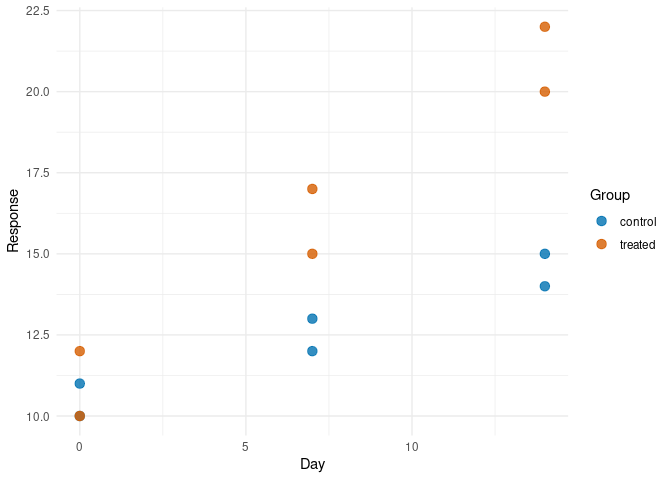

```r
p_scatter <- ggplot(df, aes(day, value, colour = group)) +
  geom_point(size = 3, alpha = 0.8) +
  scale_colour_manual(values = palette) +
  labs(x = "Day", y = "Response", colour = "Group") +
  theme_minimal()
print(p_scatter)
```

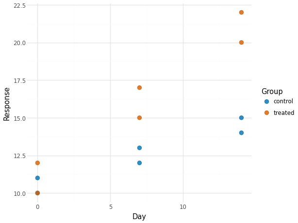

```python
p_scatter = (
    p9.ggplot(df, p9.aes("day", "value", color="group"))
    + p9.geom_point(size=3, alpha=0.8)
    + p9.scale_color_manual(values=palette)
    + p9.labs(x="Day", y="Response", color="Group")
    + p9.theme_minimal()
)
p_scatter.show()
```

Both plots show response against day, with a legend distinguishing the groups. `p9.aes(color="group")` maps a column; `p9.geom_point(color="red")` sets every point to red without a color legend. `p9.aes(color="red")` instead asks plotnine to evaluate `red`, typically causing an error when that column does not exist.

### Repeated measurements: group lines by subject

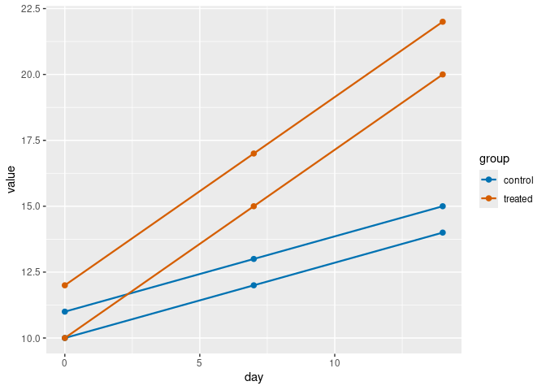

```r
p_lines <- ggplot(df, aes(day, value, colour = group, group = subject)) +
  geom_line(linewidth = 0.8) + geom_point(size = 2) +
  scale_colour_manual(values = palette)
print(p_lines)
```

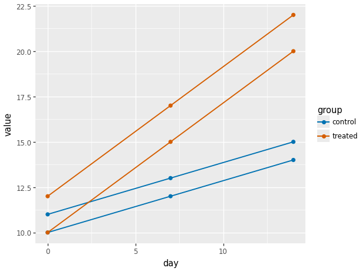

```python
p_lines = (
    p9.ggplot(df, p9.aes("day", "value", color="group", group="subject"))
    + p9.geom_line(size=0.8)
    + p9.geom_point(size=2)
    + p9.scale_color_manual(values=palette)
)
p_lines.show()
```

There should be four trajectories, with two subjects sharing each group color. Without `group="subject"`, the discrete color mapping groups by treatment and can connect different subjects. `geom_line()` orders by x within each group; `geom_path()` follows row order. For a single trajectory on a discrete x axis, `aes(group=1)` can be necessary in both languages. Modern ggplot2 uses `linewidth` for line thickness; plotnine’s [geom_line reference](https://plotnine.org/reference/geom_line.html) uses `size`.

### Bars: row counts versus precomputed values

Count observations in each group (six rows each):

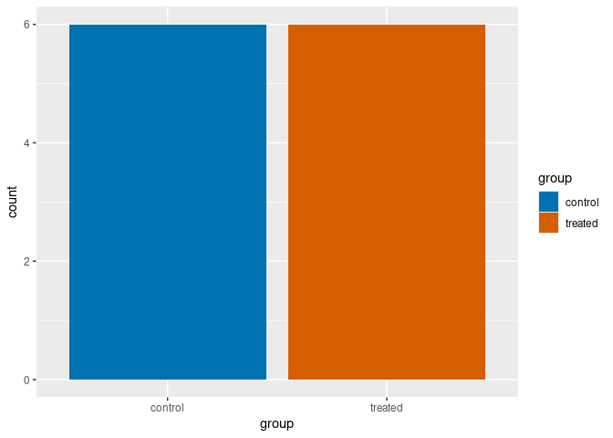

```r
ggplot(df, aes(group, fill = group)) +
  geom_bar() + scale_fill_manual(values = palette)
```

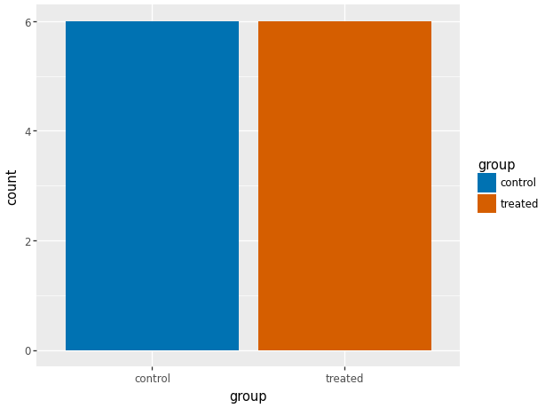

```python
p_counts = (
    p9.ggplot(df, p9.aes("group", fill="group"))
    + p9.geom_bar()
    + p9.scale_fill_manual(values=palette)
)
p_counts.show()
```

For means by group and day, summarize first and use `geom_col()`. Here `geom_bar()` would count summary rows instead of displaying their means.

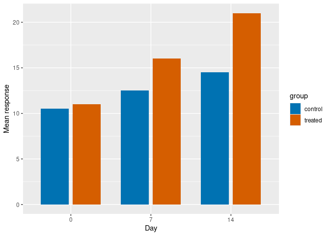

```r
summary_df <- df |>
  group_by(group, day) |>
  summarise(mean_value = mean(value), .groups = "drop")

p_bars <- ggplot(summary_df, aes(factor(day), mean_value, fill = group)) +
  geom_col(position = position_dodge(width = 0.8), width = 0.7) +
  scale_fill_manual(values = palette) +
  labs(x = "Day", y = "Mean response")
print(p_bars)
```

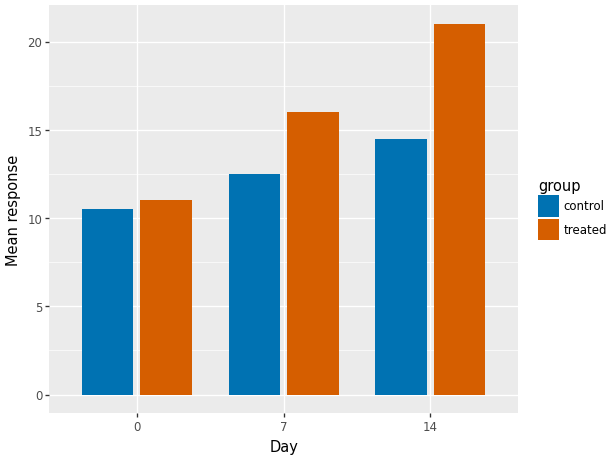

```python
summary_df = (
    df.groupby(["group", "day"], observed=True, as_index=False)
    .agg(mean_value=("value", "mean"))
)
p_bars = (
    p9.ggplot(summary_df, p9.aes("factor(day)", "mean_value", fill="group"))
    + p9.geom_col(position=p9.position_dodge(width=0.8), width=0.7)
    + p9.scale_fill_manual(values=palette)
    + p9.labs(x="Day", y="Mean response")
)
p_bars.show()
```

Control means are 10.5, 12.5, and 14.5; treated means are 11, 16, and 21. `as_index=False` keeps grouping keys as columns that plotnine can map. `observed=True` limits categorical grouping to observed combinations. `"factor(day)"` is a supported plotnine expression that gives equally spaced, discrete day labels; map `"day"` to preserve a numeric time axis.

### Histogram: computed density and explicit bins

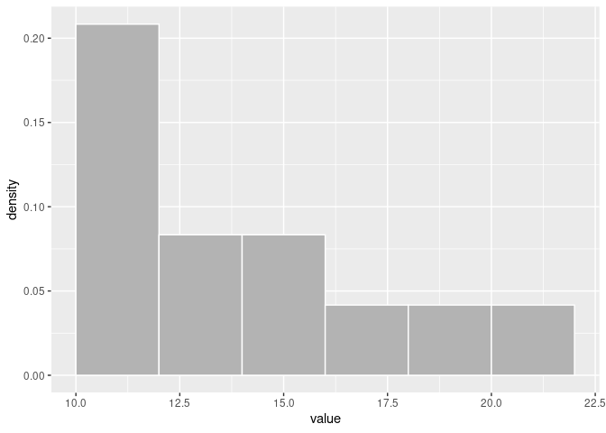

```r
ggplot(df, aes(value, y = after_stat(density))) +
  geom_histogram(binwidth = 2, boundary = 0, fill = "grey70", colour = "white")
```

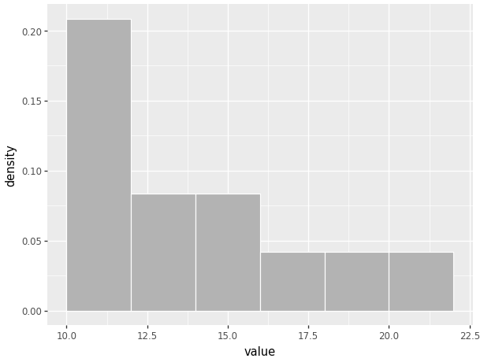

```python
p_hist = (
    p9.ggplot(df, p9.aes("value", y=p9.after_stat("density")))
    + p9.geom_histogram(binwidth=2, boundary=0, fill="#B3B3B3", color="white")
)
p_hist.show()
```

The density is calculated by the binning statistic, so it is not a column in `df`. R uses `after_stat(density)`; Python uses `p9.after_stat("density")`. Specify bin width and boundary to make bin placement comparable. R color names such as `"grey70"` are not all recognized in Python; use a hex color such as `"#B3B3B3"` for portability. Matching code still need not produce identical fonts, spacing, or rendered pixels.

### Facets and explicit smoothing

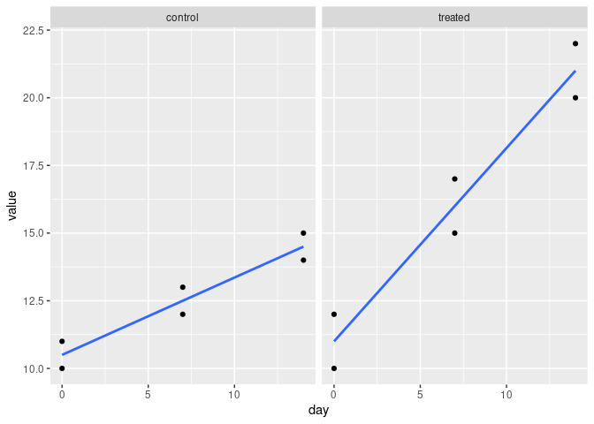

```r
p_facets <- ggplot(df, aes(day, value)) +
  geom_point() +
  geom_smooth(method = "lm", formula = y ~ x, se = FALSE) +
  facet_wrap(~group, ncol = 2)
print(p_facets)
```

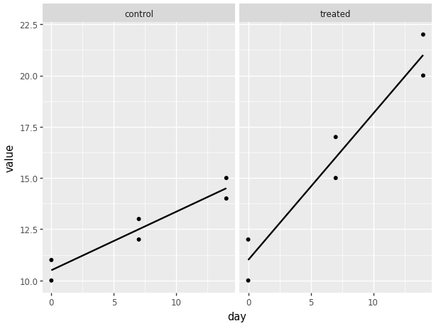

```python
p_facets = (
    p9.ggplot(df, p9.aes("day", "value"))
    + p9.geom_point()
    + p9.geom_smooth(method="lm", formula="y ~ x", se=False)
    + p9.facet_wrap("group", ncol=2)
)
p_facets.show()
```

Each panel shows one group’s observations and fitted linear trend. R facet formulas become column strings; for two variables, use `p9.facet_grid(rows="group", cols="day")`. `scales="free_y"` lets panels have different y ranges but makes visual comparisons less direct. See [facet_grid](https://plotnine.org/reference/facet_grid.html).

Smoother defaults and implementations can differ between R and Python. Choose `method="lm"` explicitly for this example. The formula is a string in Python, and its `x`/`y` refer to mapped aesthetics. Plotnine’s `loess` method requires `scikit-misc`; see [stat_smooth](https://plotnine.org/reference/stat_smooth.html).

### Themes, labels, annotations, and zoom

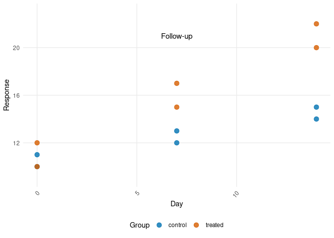

```r
p_styled <- p_scatter +
  annotate("text", x = 7, y = 21, label = "Follow-up", size = 4) +
  coord_cartesian(ylim = c(9, 23)) +
  theme(
    axis.text.x = element_text(angle = 45, hjust = 1),
    legend.position = "bottom",
    panel.grid.minor = element_blank()
  )
print(p_styled)
```

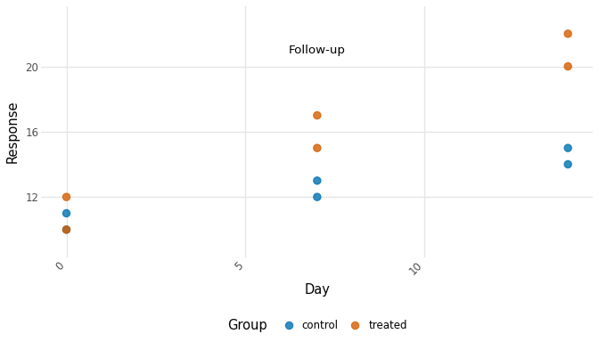

```python
p_styled = (
    p_scatter
    + p9.annotate("text", x=7, y=21, label="Follow-up", size=10)
    + p9.coord_cartesian(ylim=(9, 23))
    + p9.theme(
        axis_text_x=p9.element_text(angle=45, ha="right"),
        legend_position="bottom",
        panel_grid_minor=p9.element_blank(),
        figure_size=(7, 4),
    )
)
p_styled.show()
```

Translate dotted theme names to underscores. Plotnine text alignment uses `ha="right"`/`va="top"`, where R commonly uses numeric `hjust`/`vjust`. Text geom sizes use different units (ggplot2’s default is mm; plotnine uses points), so the annotation sizes above are approximate visual equivalents. See [element_text](https://plotnine.org/reference/element_text.html).

`coord_cartesian(ylim=...)` zooms the display while retaining data for statistics. Scale limits, such as `scale_y_continuous(limits=...)`, can remove observations before a summary or smoother is computed. This distinction matters in both languages.

### Save an image or a multipage PDF

Run these snippets only when you want to write files to the working directory.

```r
ggsave("scatter-r.png", plot = p_scatter, width = 7, height = 4,
       units = "in", dpi = 300)
pdf("plots-r.pdf", width = 7, height = 4)
print(p_scatter)
print(p_bars)
dev.off()
```

```python
p_scatter.save("scatter-python.png", width=7, height=4, units="in", dpi=300)
p9.save_as_pdf_pages(
    [p_scatter + p9.theme(figure_size=(7, 4)),
     p_bars + p9.theme(figure_size=(7, 4))],
    filename="plots-python.pdf",
)
```

Use the plot object’s [save method](https://plotnine.org/reference/ggplot.html) in place of `ggsave()`. `figure_size` is a `(width, height)` tuple in inches. `save_as_pdf_pages()` writes one plot per page; setting each plot’s theme lets you control each page’s size.

## Data preparation: translating tidyverse code

Plotnine handles plotting; pandas handles most transformations you previously performed with dplyr or tidyr.

[output not shown]

For example, combine two measurement columns into one value column and a measurement label that can be mapped to color or used for facets:

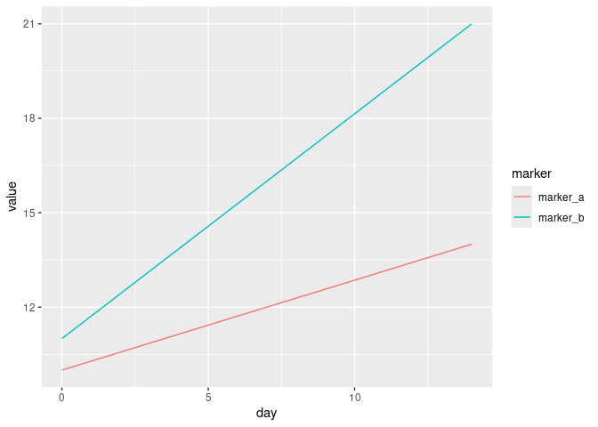

```r
wide <- data.frame(day = c(0, 7, 14), marker_a = c(10, 12, 14),
                   marker_b = c(11, 16, 21))
long <- pivot_longer(wide, cols = c(marker_a, marker_b),
                     names_to = "marker", values_to = "value")
ggplot(long, aes(day, value, colour = marker)) + geom_line()
```

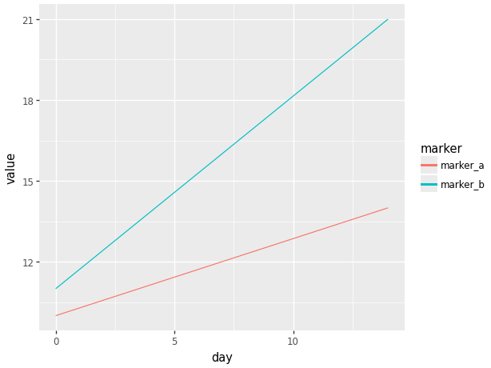

```python
wide = pd.DataFrame({
    "day": [0, 7, 14], "marker_a": [10, 12, 14], "marker_b": [11, 16, 21]
})
long = wide.melt(
    id_vars="day", value_vars=["marker_a", "marker_b"],
    var_name="marker", value_name="value",
)
p_long = (
    p9.ggplot(long, p9.aes("day", "value", color="marker"))
    + p9.geom_line()
)
p_long.show()
```

For compound filters, use parentheses around each pandas condition: `df.loc[(df["day"] > 0) & (df["group"] == "treated")]`. Python `and`/`or` do not combine pandas boolean Series; use `&`/`|`. Pandas means skip missing values by default, whereas R’s `mean()` needs `na.rm=TRUE` to do so. Make your missing-data policy explicit when comparing summaries across languages.

## Common translation problems

| Symptom | Likely cause and fix |
| --- | --- |
| A column cannot be found | Use `aes("day", "value")`; confirm spelling and that grouping keys remain columns. Rename awkward column names before using expressions. |
| A continuous legend appears for category codes | Convert the numeric column to a pandas categorical before mapping it. |
| Lines join unrelated observations | Set `group` to the subject or series identifier. |
| Bars display counts instead of means | Use `geom_col()` with the prepared y column. |
| Python rejects a multiline plot | Wrap the full `ggplot(...) + ...` expression in parentheses. |
| Python rejects `linewidth` or a dotted keyword | Check the geom reference; use `size` for these line examples and underscored argument names. |
| A script runs but no plot appears | Call `p.show()` or save the plot explicitly. |
| A smoother changes after applying limits | Use coordinate zoom if you want statistics based on the full data. |
| An R extension function is unavailable | ggplot2 extensions do not transfer automatically; find a Python implementation or reconstruct the layer from prepared data. |

When adapting a larger R plot, translate data preparation first, add one layer at a time, and compare grouping, category order, summaries, and axis ranges before tuning its appearance. Record package versions for reproducible work: `packageVersion("ggplot2")` in R, and `p9.__version__` / `pd.__version__` in Python.